# Using Mixscale to analyze Perturb-seq data

## Section B.

In this section we will focus on how to use the pathway signatures from our study to run gene set enrichment test in external datasets.

### 0. Introduction

We will use the interferon-beta (IFNB) stimulated human PBMCs dataset (ifnb) from [Kang et al 2017](https://www.nature.com/articles/nbt.4042) (available via [SeuratData](https://github.com/satijalab/seurat-data) package) to demonstrate how to perform gene set enrichment analyses using the pathway gene sets from our study. We aim to show that by using our pathway gene lists, we can correctly infer the pathway activation of IFNB across different cell types in the human PBMCs.

```r
# install the ifnb dataset
SeuratData::InstallData("ifnb")
# load dataset
ifnb <- SeuratData::LoadData("ifnb")
```

We can then load the pathway gene sets we generated (can be downloaded from Zenodo). There are two versions of pathway gene lists provided. One is the standard pathway gene list for different pathway programs we compiled, and the other one is the pathway exclusive gene list that filtered out the shared genes shared with other relevant pathways in the experiment.

```r
plist = readRDS("Pathway_genelist.rds")
exclusive_plist = readRDS("Pathway_Exclusive_genelist.rds")

# only extract the exclusive gene lists that are relevant to IFNB pathway
exclusive_plist = exclusive_plist[c("IFNG_REMOVE_IFNB", "IFNB_REMOVE_IFNG",
                                    "IFNB_REMOVE_TNFA", "TNFA_REMOVE_IFNB")]
```

### 1. DE tests and Fisher enrichment tests for ifnb dataset

We will first conduct Wilcox DE tests between the control and the IFNB-stimulated cells in each cell types in the ifnb dataset. Then, we will perform Fisher enrichment tests for the DE genes from each of the cell types, testing them against the pathway gene lists we just load. These two steps are merged by a wrapper function.

```r
# Normalize the counts
ifnb = NormalizeData(ifnb)

# A wrapper function to perform both DE and enrichment test
res = Mixscale_DEenrich(object = ifnb,
                        plist = plist,
                        labels = "seurat_annotations",
                        conditions = "stim",
                        ident.1 = "STIM",
                        ident.2 = "CTRL",
                        direction = "up",
                        logfc.threshold = 0.2,
                        p.val.cutoff = 0.05,
                        min.pct = 0.1)

# check the enrichment results for CD14 Monocytes
head(res$`CD14 Mono`)
```

```
##              GO_term        OR         Pval   combined_score num_LH num_PH
## 1 IFNB_program1_down 30.551460 1.566042e-69 4840.26233710267    148    164
## 3 IFNG_program1_down 13.764122 6.311636e-47 1464.21496809152    125    154
## 5 TNFA_program1_down  7.315289 8.145677e-26 422.602219842384     91    128
## 4 IFNG_program2_down 14.092937 5.223443e-21 658.156092839788     54     64
## 2 IFNB_program2_down  1.353308 1.792922e-01  2.3259826904708     20     57
## 6 TNFA_program2_down  1.537152 3.469431e-01 1.62722098095663      5     11
##   n_GO_term num_DEG direction_DEG
## 1       300     590         upDEG
## 3       300     590         upDEG
## 5       300     590         upDEG
## 4       200     590         upDEG
## 2       223     590         upDEG
## 6        98     590         upDEG
```

### 2. Enrichment tests using pathway exclusive gene lists

Gene lists from related pathways, such as IFNG, IFNB, and TNFA which are all linked to immune responses, frequently share many genes. This overlap makes it challenging to differentiate the activation of these pathways. For example, as the result above shows, DE genes due to IFNB stimulation are enriched in not just the IFNB pathway, but also in IFNG and TNFA pathways. To overcome this challenge, we have introduced a concept of pathway-exclusive gene lists. Essentially, for any two related pathways, we define the exclusive genes of one pathway as those that are absent from the gene list of the other. To refine this further, we employed a more stringent criterion to exclude genes that, while potentially related, are not explicitly listed in the gene list of the other pathway (For a detailed explanation, please refer to our paper). Performing enrichment tests using the exclusive gene lists enhances our ability to accurately distinguish activations among closely associated pathways.

```r
# A wrapper function to perform both DE and enrichment test
res_exclusive = Mixscale_DEenrich(object = ifnb,
                        plist = exclusive_plist,
                        labels = "seurat_annotations",
                        conditions = "stim",
                        ident.1 = "STIM",
                        ident.2 = "CTRL",
                        direction = "up",
                        logfc.threshold = 0.2,
                        p.val.cutoff = 0.05,
                        min.pct = 0.1)

# check the enrichment results for CD14 Monocytes
head(res_exclusive$`CD14 Mono`)
```

```
##            GO_term        OR         Pval       combined_score num_LH num_PH
## 3 IFNB_REMOVE_TNFA 9.8573087 8.350578e-30     659.998290889661     90    117
## 2 IFNB_REMOVE_IFNG 9.8435531 1.200209e-19     428.850346678085     58     74
## 1 IFNG_REMOVE_IFNB 1.7696262 6.530225e-02     4.82882984756938     16     38
## 4 TNFA_REMOVE_IFNB 0.1313289 9.999754e-01 3.22910851679664e-06      3     42
##   n_GO_term num_DEG direction_DEG
## 3       433     590         upDEG
## 2       289     590         upDEG
## 1       198     590         upDEG
## 4       188     590         upDEG
```

We can see that the exclusive gene lists for IFNB (removing TNFA) and IFNB (removing IFNG) are still enriched for IFNB-stimulated DE genes. But we do not observe signals from IFNG (removing IFNB) or TNFA (removing IFNB), indicating that the underlying activated pathway during IFNB stimulation is indeed IFNB, while IFNG and TNFA are showing enrichment just because of their substantial overlap with IFNB.

### 3. Visualization

We can now visualize the enrichment results across all the cell types in the ifnb dataset. First we will check the results for the standard enrichment test

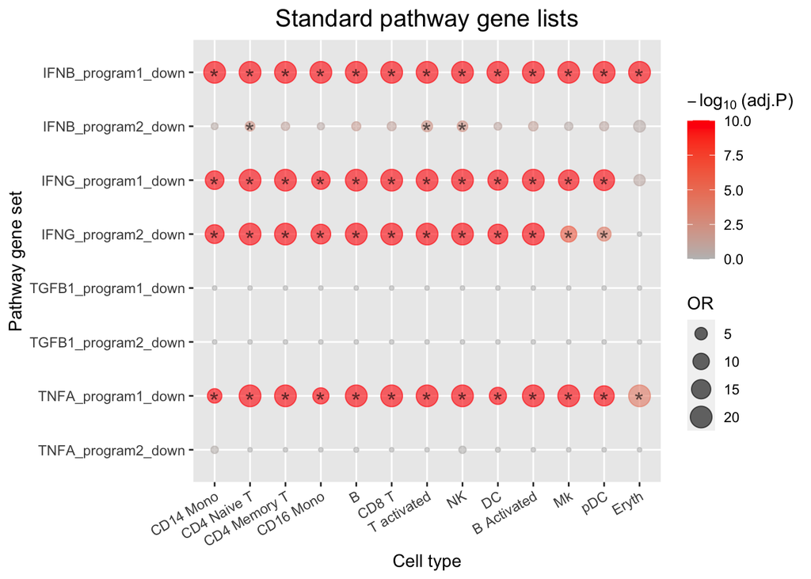

```r
DEenrich_DotPlot(res,
                 direction = "up",
                 plot_title = "Standard pathway gene lists")
```

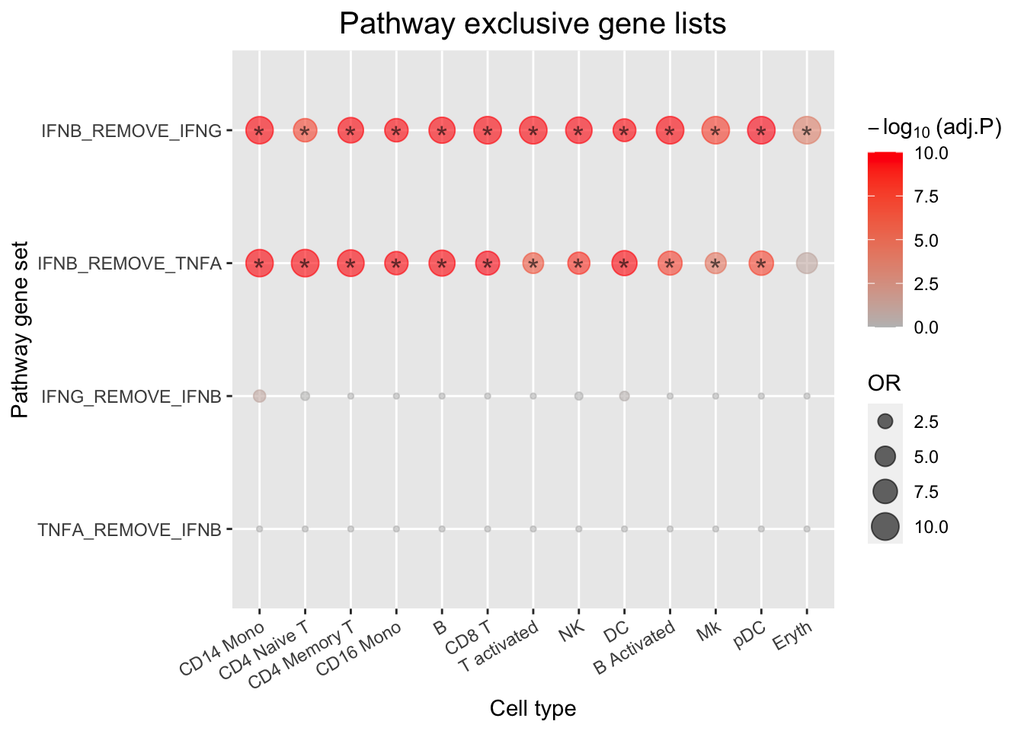

```r
DEenrich_DotPlot(res_exclusive,
                 direction = "up",
                 plot_title = "Pathway exclusive gene lists",
                 OR_cutoff = 10)
```

### 4. Module score analysis

Apart from performing enrishment test, we can also evaluate the pathway activity by calculating the over all expression level of all the genes within a gene list (the so-called module score analysis). We will use package [“UCell”](https://bioconductor.org/packages/release/bioc/html/UCell.html) for module score analysis. Alternatively, we can use the built-in function [AddModuleScore()](https://satijalab.org/seurat/reference/addmodulescore) from Seurat as well.

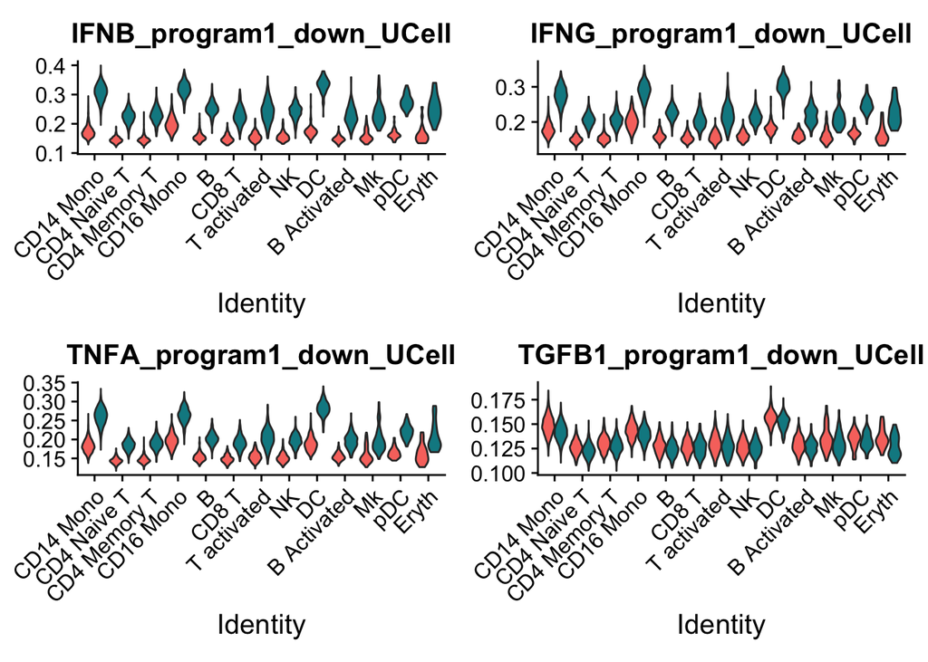

```r
ifnb = UCell::AddModuleScore_UCell(ifnb,
                                   features = plist[c("IFNB_program1_down", "IFNG_program1_down",
                                                      "TNFA_program1_down", "TGFB1_program1_down")] )

# using VlnPlot to visualize the score of each cell
VlnPlot(ifnb,
             features = grep("_UCell", names(ifnb@meta.data), value = T),
             pt.size = 0,
             group.by = "seurat_annotations",
             split.by = "stim",
             ncol = 2) &
    theme(legend.position = "NA",
          axis.title = element_text(size = 15),
          axis.text = element_text(size = 12),
          plot.title = element_text(size = 15))
```

We can observe very similar results as in our enrichment tests, where all IFNB, IFNG, and TNF pathways show a high activity (and not for TGFB pathway) in the IFNB-stimulated cells compared to the non-stimulated cells. And if we repeat the module score analysis using the pathway exclusive gene lists, we should be able to determine the pathway actually being activated (i.e., IFNB pathway).

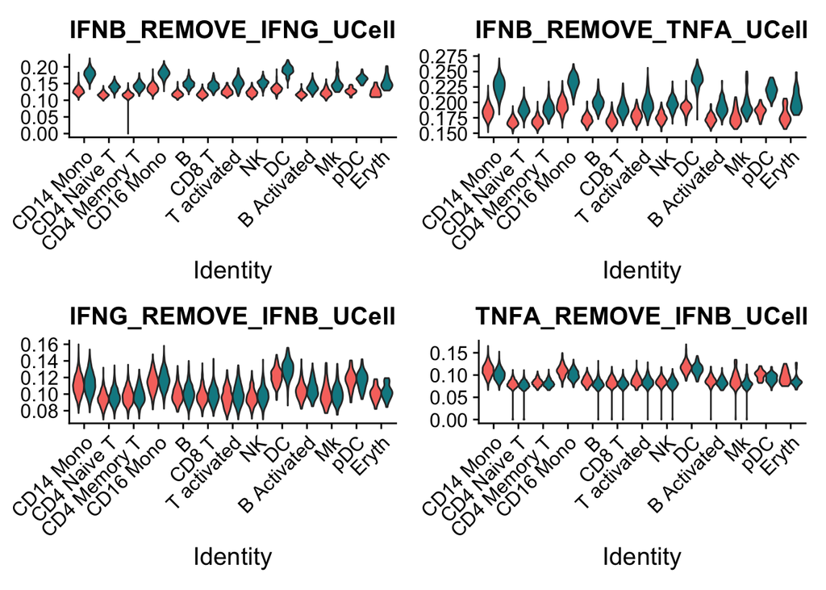

```r
ifnb = UCell::AddModuleScore_UCell(ifnb,
                                   features = exclusive_plist[c("IFNB_REMOVE_IFNG", "IFNB_REMOVE_TNFA",
                                                                "IFNG_REMOVE_IFNB", "TNFA_REMOVE_IFNB")] )

# using VlnPlot to visualize the score of each cell
VlnPlot(ifnb,
             features = grep("_REMOVE_.*UCell", names(ifnb@meta.data), value = T),
             pt.size = 0,
             group.by = "seurat_annotations",
             split.by = "stim",
             ncol = 2) &
    theme(legend.position = "NA",
          axis.title = element_text(size = 15),
          axis.text = element_text(size = 12),
          plot.title = element_text(size = 15))
```